# boun58d Package Introduction

BOUN - ETM58D

Mar 29, 2017

This document is written as an introduction to `boun58d` R package. This package contains helper functions and data for the students of BOUN 58D - Business Analytics course at Bogazici University, Turkey.

# Installation

## devtools

First you need to install the package from GitHub. R 3.3.3 version is recommended. Install the `devtools` package if you haven’t already in order to install R packages from GitHub.

```r
#Install only once, if you haven't installed.
install.packages("devtools")
```

## boun58d

Now that you have installed `devtools`, let’s install our package from GitHub. You can visit the repository at https://github.com/r338/boun58d/.

```r
#Install the package from Github
devtools::install_github("r338/boun58d")
```

## Poloniex

As a last step you need to create an account at Poloniex exchange and create API credentials.

1. Go to poloniex.com and create an account.
2. When you log in go to API keys section.

[figure not shown]

3. Create your API key and secret (sign).

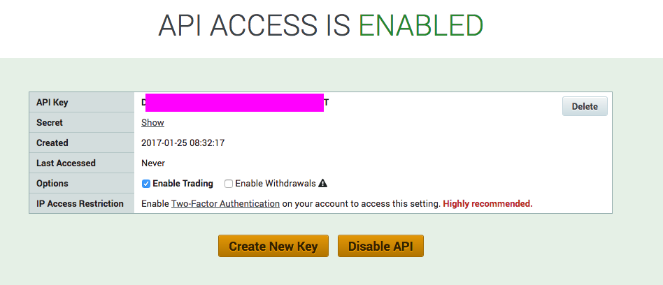

# Usage

We start by calling the library.

```r
#First call the library
library(boun58d)
```

## Setting Credentials

To get more extensive data and do some operations, you will need user credentials (i.e. API key and secret/sign). You only need to set it once. `set_authorization` function in the package will provide you that functionality.

```r
#Set your authorization once

set_authorization(Key="WRITE YOUR API KEY HERE",Sign="WRITE YOUR API SECRET HERE",file_name="my_poloniex_credentials")
```

Your credentials will be saved to an “.rds” file. This file is not encrypted or so, you need to keep it safe.

## Getting Data

Now that we are all set, we can start harvesting data from the server. Poloniex has a pretty clear documentation on the data gathering exercises. See all the commands on https://poloniex.com/support/api/. We are going to do it using our package’s `get_from_poloniex`. Our commands are listed under “Public API Methods”. We can use “returnTicker”, “return24Volume”, “returnOrderBook”, “returnTradeHistory”, “returnChartData”, “returnCurrencies” and “returnLoanOrders”.

What we need is “returnChartData”. You can try the rest of them yourself. You need to define a start point, end point and interval. All values should be numeric, so you need to make adjustments to your date.

```r
#Define start and end points
#We use POSIXct format for dates, then convert to numeric.
start_point = as.numeric(as.POSIXct("2017-03-28 00:00:00",tz="Europe/Moscow"))
end_point = as.numeric(as.POSIXct("2017-03-28 23:55:00",tz="Europe/Moscow"))
print(start_point)
```

```
## [1] 1490648400
```

```r
print(end_point)
```

```
## [1] 1490734500
```

```r
#Define a period value in seconds. Valid periods are 300, 900, 1800, 7200, 14400, and 86400)
#Let's define 5-min intervals
period_value<- 300
#Get the data
chartData <- get_from_poloniex("returnChartData",parameters=list(currencyPair = "BTC_ETH",start=start_point,end=end_point,period=period_value))
#Convert chartData into a data.table data frame with data.table::rbindlist
chartData <- data.table::rbindlist(chartData)
chartData
```

```
##            date       high        low       open      close    volume
##   1: 1490648400 0.04866990 0.04851230 0.04861055 0.04854921  64.30565
##   2: 1490648700 0.04879399 0.04851341 0.04854921 0.04870191 105.38790
##   3: 1490649000 0.04878400 0.04846223 0.04870000 0.04860000  70.92026
##   4: 1490649300 0.04872697 0.04846250 0.04860000 0.04857007  23.78718
##   5: 1490649600 0.04874196 0.04846223 0.04857007 0.04859990  42.42183
##  ---
## 284: 1490733300 0.04835870 0.04822300 0.04831999 0.04825000  52.51200
## 285: 1490733600 0.04844198 0.04823854 0.04825000 0.04836001  48.35137
## 286: 1490733900 0.04843698 0.04838501 0.04841200 0.04843252  10.18835
## 287: 1490734200 0.04881017 0.04843252 0.04843698 0.04880000  88.35487
## 288: 1490734500 0.04881018 0.04870004 0.04880000 0.04871011  48.71024
##      quoteVolume weightedAverage
##   1:   1324.3350      0.04855693
##   2:   2169.2891      0.04858176
##   3:   1460.8683      0.04854665
##   4:    489.9449      0.04855071
##   5:    874.3527      0.04851798
##  ---
## 284:   1087.9597      0.04826649
## 285:   1000.3626      0.04833384
## 286:    210.3910      0.04842577
## 287:   1815.6826      0.04866206
## 288:    998.6865      0.04877430
```

## Analysis

Now, let’s dig into our intraday 5-min data a bit. We are going to use `tidyverse` for data manipulation and visualization. Install them if you haven’t already installed.

```r
# install.packages("tidyverse")
# install.packages("tidyquant")
options(dplyr.width=Inf)
library(tidyverse)
library(tidyquant)
```

First step, convert dates to a date format.

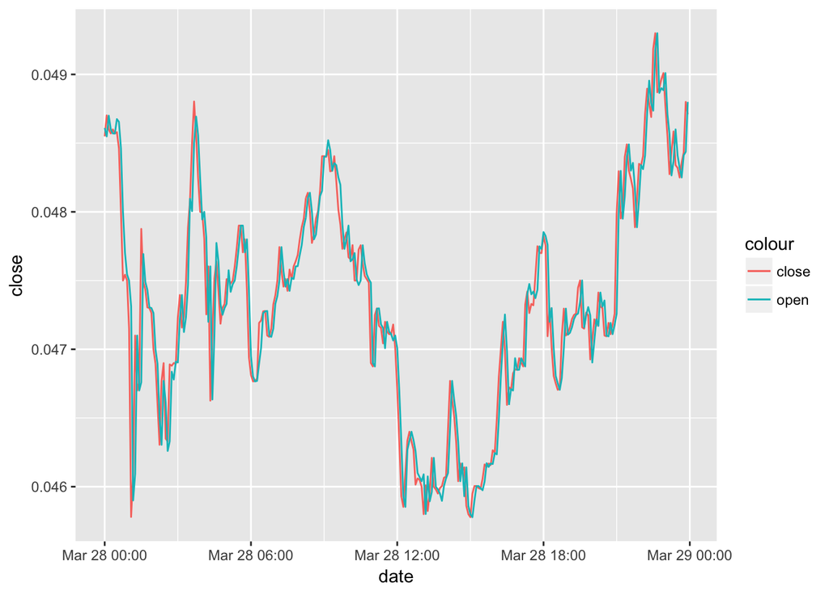

```r
chart_df<-
chartData %>%
    mutate(date=as.POSIXct(date, origin="1970-01-01")) %>%
    tbl_df


#Here is a ggplot
ggplot(data=chart_df,aes(x=date)) + geom_line(aes(y=close,color="close")) + geom_line(aes(y=open,color="open"))
```

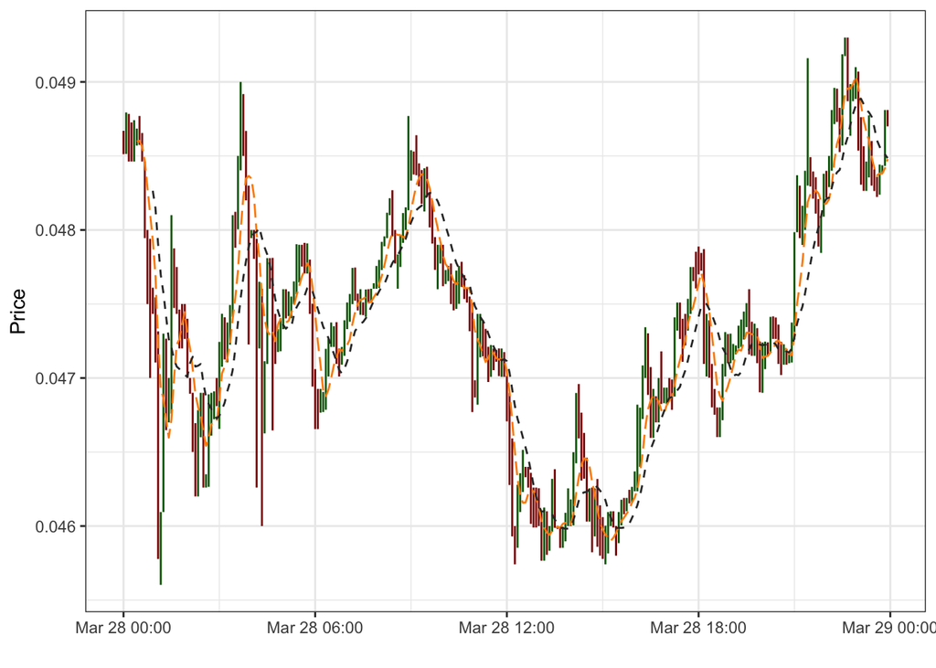

```r
#Perhaps we can do better with tidyquant package
ggplot(data=chart_df,aes(x=date,y=close)) +
#Plot candlestick chart
geom_candlestick(aes(open = open, high = high, low = low, close = close),color_up = "darkgreen", color_down = "darkred", fill_up  = "darkgreen", fill_down  = "darkred",show.legend = TRUE) +
#Plot half-hour simple moving averages
geom_ma(ma_fun = SMA, n = 6, color="darkorange", linetype = 5, size = 0.5, show.legend=TRUE) +
#Plot hourly simple moving averages
geom_ma(ma_fun = SMA, n = 12, color = "#333333", size = 0.5, show.legend=TRUE) +
labs(x="",y="Price") +
theme_bw() +
theme()
```